# Differential expression and abundance between conditions

Sept 2022

## Single Cell RNAseq Analysis Workflow

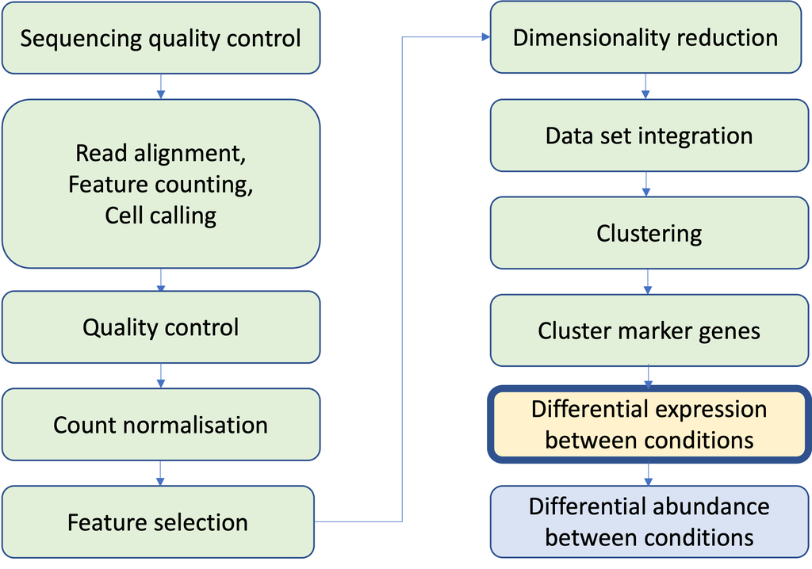

## Outline

Clusters and/or cell types have been identified, we now want to compare sample groups:

- Differential expression - Differences in expression between sample group within a biological state.
- Differential abundance - Differences in cell numbers between sample groups within a biological state.

## Differential Expression

Replicates are samples not cells:

- single cells within a sample are not independent of each other,
- using cells as replicates amounts to studying variation inside an individual
- while we want to study variation across a population

Pseudo-bulk:

- gene expression levels for each cluster in each sample
- are obtained by summing across cells

## Differential expression between conditions

Workflow:

- compute pseudo-bulk count by summing across cells,
  - per cluster and per sample
- perform bulk analysis with fewer replicates,
  - for each cluster separately

Method:

- quasi-likelihood (QL) methods from the `edgeR` package
- negative binomial generalized linear model (NB GLM)
  - to handle overdispersed count data
  - in experiments with limited replication

## Differential Expression

Steps:

- Remove samples with very low library sizes, e.g. < 20 cells
  - better normalisation
- Remove genes that are lowly expressed,
  - reduces computational work,
  - improves the accuracy of mean-variance trend modelling
  - decreases the severity of the multiple testing correction
  - filter: log-CPM threshold in a minimum number of samples, smallest sample group
- Correct for composition biases
  - by computing normalization factors with the trimmed mean of M-values method
- Test whether the log-fold change between sample groups is significantly different from zero
  - estimate the negative binomial (NB) dispersions
  - estimate the quasi-likelihood dispersions, uncertainty and variability of the per-gene variance

## Differential Abundance

Aim:

- test for significant changes in grouped cell abundance across conditions

Example:

- which cell types are depleted or enriched upon treatment?

## Differencial Abundance - Milo

- Most methods require defined clusters as input. Assigning cells to discrete clusters in context of continuous differentiation, developmental or stimulation trajectories.
- Methods that don’t require clusters also don’t model variability in cell numbers among replicates or can only carry out pairwise comparisons.

Milo

- Uses K- nearest neighbour graph to model cellular states as overlapping neighbourhoods. Non-independence is accounted for with a weighted version of the Benjamini–Hochberg method.
- Determines neighbourhoods and groupings independently of our defined clusters
- Can be used for complex models
- Faster and scalable

## Differencial Abundance - Milo

Steps:

- Construct KNN graph
  - rescales UMI count by per-cell sequencing depth
  - log transforms
  - uses PCA
  - calculates Euclidean distance between cells and its k nearest neighbour in PC space
- Defines Cell Neighbourhoods
- Counts cells in Neighbourhoods
- Tests for DA in Neighbourhoods
- Does a multiple testing correction (Spacial FDR)
- Visualiations